# hw04

Ting An Lai

2019-10-14

# 1. Functions in the dplyr Package

```r
# Making sure we all have the same version. Please execute chunk once.
#install.packages("devtools")
#devtools::install_github("tidyverse/dplyr")
```

```r
# Get all functions in dplyr
library(dplyr)
```

```r
content <- mget(ls("package:dplyr"), inherits = TRUE)
dplyr_functions <- Filter(is.function, content)
```

#### a) Longest name

#### Use the appropriate map function to produce a vector of the names of all functions in the dplyr package. Which function has the longest name?

group_by_drop_default

```r
library (purrr)
fun_name_len = map_int (names (dplyr_functions), nchar)
longest_name_index = sort (fun_name_len, decreasing = TRUE)[1]
names (dplyr_functions)[fun_name_len == longest_name_index]
```

```
[1] "group_by_drop_default"
```

```
group_by_drop_default
```

#### b) Number of arguments

#### Use the appropriate map function to calculate the number of arguments by function. Present a table of the Top 10 functions with the most arguments. Which function has the most arguments? Hint: Remember that the functions formals(), body(), and environment() allow you to access parts of a function.

sql_select has the most arguments, 10.

```r
fun_arg_list = map (dplyr_functions[], formals )
fun_arg_length = map (fun_arg_list[], length)
sorted_arg_length = sort (unlist (fun_arg_length), decreasing = TRUE)
```

```r
as.table (sorted_arg_length[1:10])
```

```
     sql_select       nest_join        sql_join       all_equal
             10               7               7               6
  compare_tbls2           count db_create_index  db_write_table
              6               6               6               6
        enexprs          enquos
              6               6
```

#### c) Most common argument

#### Which function arguments are the top 5 most common. Briefly explain what the most common argument does?

1.The most common argument is … which is additional arguments passed on to the function. 2. The second common argument is x, which is the object that the function has major function on. 3. The third common is tbl, which is table 4. The fourth common is data, which is the dataset that the method is exerted on 5. The fifth common is funs, which is list of functioms.

```r
all_arg = gsub (".*\\.", '', names (unlist (fun_arg_list)))
sort (table (all_arg), decreasing = TRUE) [1:5]
```

```
all_arg
        x  tbl data funs
 150   85   47   36   33
```

# 2. Infant Mortality and GPD per Capita

#### a) Highest and lowest infant mortality rates in 2018

```r
#install.packages('WDI')
library(WDI)
df = WDI(country = "all", indicator = c ("NY.GDP.PCAP.PP.KD", "SP.DYN.IMRT.IN"), start = 1960, end = 2018, extra = TRUE, cache = NULL)
```

### Rename the variables: infant mortality (infmort) and GPD per capita (gdpcap). Keep only entries for countries (i.e. remove entries for regions and the World as a whole).

```r
colnames(df)[(names(df) == "NY.GDP.PCAP.PP.KD")] <- "infmort"
colnames(df)[(names(df) == "SP.DYN.IMRT.IN")] <- "gdpcap"
df <- subset(df, region != "Aggregates")
```

#### Present a list of countries with the 5 highest and the 5 lowest infant mortality rates in 2018 along with their GDP per capita in that year.

```r
subdf <- df %>%
  filter (year == 2018) %>%
  select ("country", "year", "infmort", "gdpcap") %>%
  na.omit ()


FiveLowest = subdf[order(subdf$infmort)[1:5],c ("country", "year", "infmort", "gdpcap")]
FiveHighest = subdf[order(subdf$infmort, decreasing = TRUE)[1:5],c ("country", "year", "infmort", "gdpcap")]
```

```r
FiveLowest
```

|  | country | year | infmort | gdpcap |
| --- | --- | --- | --- | --- |
| 21 | Burundi | 2018 | 660.2656 | 41.0 |
| 34 | Central African Republic | 2018 | 774.6877 | 84.5 |
| 33 | Congo, Dem. Rep. | 2018 | 827.1383 | 68.2 |
| 142 | Niger | 2018 | 931.9875 | 48.0 |
| 114 | Liberia | 2018 | 1161.1779 | 53.5 |

```r
FiveHighest
```

|  | country | year | infmort | gdpcap |
| --- | --- | --- | --- | --- |
| 163 | Qatar | 2018 | 112531.53 | 5.8 |
| 117 | Luxembourg | 2018 | 93734.28 | 1.9 |
| 173 | Singapore | 2018 | 90091.42 | 2.3 |
| 24 | Brunei Darussalam | 2018 | 71802.46 | 9.8 |
| 86 | Ireland | 2018 | 70855.33 | 3.1 |

#### b) Overall regression

#### Run an overall regression predicting infant mortality from GDP per capita. What do you find? Make a scatter plot (including a regression fit line).

The relationship between GDP and infant mortality is negative. However, the linear relatinoship might not be the best for describing the negative relationship.

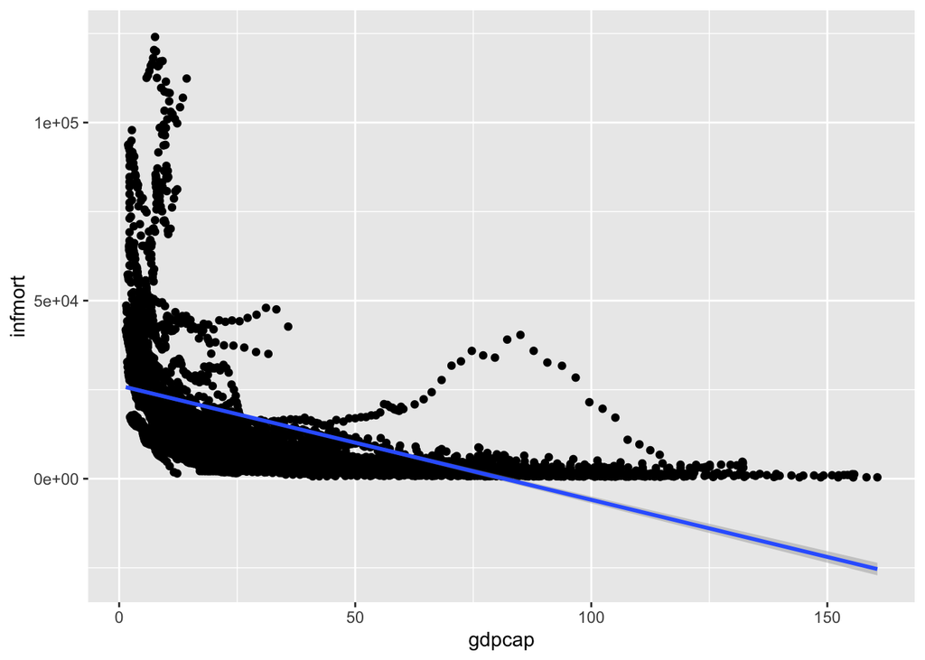

```r
subreg <- df %>%
  select ("country", "year", "infmort", "gdpcap") %>%
  na.omit

reg = lm (subreg$infmort ~subreg$gdpcap)

library(ggplot2)
ggplot(subreg, aes(x = gdpcap, y = infmort)) +
  geom_point() +
  geom_smooth(method='lm',formula=y~x)
```

#### c) Regression by region

#### Let’s see if the overall relationship holds within world regions. Split the the data by region and create a nested list that contains these split data frames. In a single pipeline, re-estimate the regression for each of these data frames, obtain the coefficient estimates for the slope for each region and present them in a table (sorted by size of the coefficient).

```r
df$region <- factor (df$region)

subregion <- df
region_coef <-subregion  %>%
  select ('infmort', 'gdpcap', 'region') %>%
  na.omit ()  %>%
  split ( subregion$region) %>%
  map (~lm (infmort ~gdpcap, data =.), safely(subregion)) %>%
  map (~coef (.)) %>%
  map_dbl ('gdpcap') %>%
  sort ()
region_coef
```

```
     Europe & Central Asia         Sub-Saharan Africa
                 -373.2713                  -331.7199
       East Asia & Pacific                 South Asia
                 -327.2619                  -307.6148
             North America Middle East & North Africa
                 -298.2772                  -290.2224
 Latin America & Caribbean
                 -271.1709
```

#### d) Regression by country

#### Let’s also check if the relationship is consistent if estimated within countries. Split the overall data by country and create a nested list that contains these split data frames.

```r
# dataframe preprocessing
subcount <- df
t = table (subcount$country)
levels(subcount$country) <- names (t)
subcount <- na.omit (subcount)


# pipeline
coef_rank <- subcount %>%
  split(subcount$country) %>%
  map (~lm (infmort ~gdpcap, data =.), safely (coef_rank)) %>%
  map (~coef (.)) %>%
  map_dbl ('gdpcap') %>%
  sort (decreasing = TRUE)

# summary
coef_rank_summary <- subcount %>%
  split(subcount$country) %>%
  map (~lm (infmort ~gdpcap, data =.), safely (coef_rank)) %>%
  map (~summary (.)) %>%
  map_dbl('adj.r.squared')


#check conf interval
confin_rank <- subcount %>%
  split(subcount$country) %>%
  map (~lm (infmort ~gdpcap, data =.)) %>%
  map (~summary (.)) %>%
  map (confint)

coef_rank
```

```
          United Arab Emirates                     San Marino
                  7.269140e+03                   2.701898e+03
                        Kuwait                          Libya
                  1.799370e+03                   3.767621e+02
                   South Sudan                          Gabon
                  1.932442e+02                   1.609640e+02
                      Dominica                          Haiti
                  1.345236e+02                   6.360582e+00
      Central African Republic               Congo, Dem. Rep.
                  4.468929e+00                   3.226165e+00
                 Guinea-Bissau                        Burundi
                  2.750045e+00                   2.705011e+00
               Solomon Islands                     Madagascar
                  2.296919e+00                   1.557526e+00
                       Liberia                    Yemen, Rep.
                 -3.559894e-02                  -8.257832e-02
                      Zimbabwe                          Niger
                 -1.913295e-01                  -7.926338e-01
                      Kiribati                    Gambia, The
                 -1.140351e+00                  -2.118046e+00
                 Cote d'Ivoire                        Eritrea
                 -2.330822e+00                  -3.019709e+00
                        Malawi                        Comoros
                 -3.742076e+00                  -3.944615e+00
                          Togo                   Sierra Leone
                 -6.249479e+00                  -6.754828e+00
                    Mozambique                         Guinea
                 -7.678908e+00                  -8.560042e+00
                        Rwanda                           Mali
                 -1.143457e+01                  -1.269084e+01
                      Ethiopia                     Tajikistan
                 -1.311110e+01                  -1.320065e+01
                        Uganda                          Benin
                 -1.388002e+01                  -1.401181e+01
                         Kenya          Micronesia, Fed. Sts.
                 -1.496341e+01                  -1.500449e+01
                  Burkina Faso                       Tanzania
                 -1.594008e+01                  -1.886675e+01
                      Cameroon                          Nepal
                 -1.900302e+01                  -1.908705e+01
```

[output cut: 131 more lines]

```
                 -3.666466e+03                  -3.763059e+03
                         Malta                        Finland
                 -3.798592e+03                  -4.418423e+03
                     Australia                    Switzerland
                 -4.582314e+03                  -4.614474e+03
                   Netherlands                         Norway
                 -4.980408e+03                  -5.124981e+03
                        Sweden                  United States
                 -5.266013e+03                  -5.404976e+03
                       Iceland                         Canada
                 -5.513617e+03                  -6.839553e+03
                    Luxembourg                        Ireland
                 -7.759819e+03                  -7.861944e+03
                     Singapore
                 -1.243700e+04
```

#### Again, estimate a simple linear regression, predicting infant mortality by GDP per capita. In what percentage of the within-country regressions do we find a positive relationship (at the 95% confidence level) between GDP per capita and infant mortality?

7.57 %

```r
sum(coef_rank > 0) / length (coef_rank) *100
```

```
[1] 7.567568
```

#### Make a histogram of the slope coefficients to illustrate the variation of the estimated relationship. Which country cases are most at odds with the overall regression estimated in part (b)?

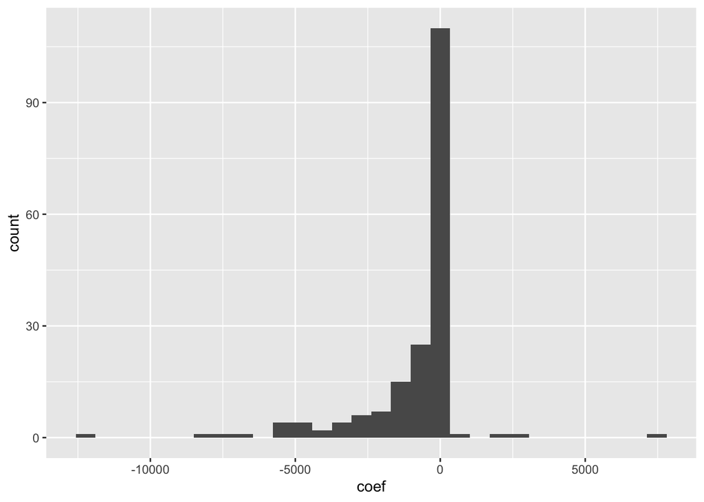

```r
coef_df = as.data.frame(coef_rank)

g <- ggplot(coef_df, aes(x=coef_rank)) +
  geom_histogram() +
  xlab ("coef")
g
```

Singapore’s coefficients is the most at odds with the overall coefficients

```r
reg_coef = summary (reg)$coefficients[2]
int = coef_rank - reg_coef
ab_int = abs (int )
sort (ab_int, decreasing = TRUE)
```

```
                     Singapore           United Arab Emirates
                  12116.163224                    7589.978367
                       Ireland                     Luxembourg
                   7541.106313                    7438.981318
                        Canada                        Iceland
                   6518.715065                    5192.779061
                 United States                         Sweden
                   5084.138090                    4945.175397
                        Norway                    Netherlands
                   4804.142658                    4659.570351
                   Switzerland                      Australia
                   4293.635989                    4261.475717
                       Finland                          Malta
                   4097.584939                    3477.753804
                United Kingdom                        Germany
                   3442.221264                    3345.627790
                       Denmark                     San Marino
                   3237.306059                    3022.735449
                   New Zealand                        Austria
                   2902.718658                    2895.694672
               Slovak Republic                      Lithuania
                   2572.284151                    2269.886454
                       Belgium                         France
                   2226.144819                    2218.618326
                         Japan                         Kuwait
                   2204.344970                    2120.208253
                   Korea, Rep.                          Spain
                   2070.069328                    2053.853567
                      Slovenia            Trinidad and Tobago
                   1986.787768                    1695.818611
                       Croatia                         Israel
                   1649.880219                    1446.227036
                       Estonia                 Czech Republic
                   1441.240187                    1410.512816
                         Nauru                       Malaysia
                   1355.402545                    1297.587613
                         Chile                          Qatar
                   1189.689522                    1142.488610
                        Cyprus                         Poland
                   1140.537414                    1139.457898
```

[output cut: 131 more lines]

```
                     84.539102                      83.914071
                       Namibia                       Suriname
                     83.297633                      76.731644
                         Tonga                          Samoa
                     76.602575                      59.173624
                        Turkey                   Turkmenistan
                     51.376795                      42.241473
                         China              Brunei Darussalam
                     37.273570                      32.093402
                      Colombia                           Oman
                     26.243537                      14.204209
                      Botswana            Antigua and Barbuda
                     12.869498                      10.168790
                       Albania
                      7.205858
```

5. Added squared term

#### Let’s see if we can improve the models slightly. Using the list of country data frames from (d), estimate regressions of infant mortality on GDP per capita and the square of GDP per capita.

#### Compare the adjusted R-Squareds of the models with and without the added squared term of GDP per capita.

The adjusted R-squared without added squared term had in general a lower adjusted r-squared score.

```r
adjr_rank_sqr <- subcount %>%
  split(subcount$country) %>%
  map (~lm (infmort ~ sqrt (gdpcap) + gdpcap, data =.), safely (adjr_rank_sqr))  %>%
  map (~summary (.)) %>%
  map ('adj.r.squared')


# str (coef_rank_sqr)
adjr_rank_sqr = unlist (adjr_rank_sqr)
adjr_without_sqr =  coef_rank_summary
adjr_rank_sqr [1:15]
```

```
        Afghanistan             Albania             Algeria
          0.9049669           0.9800686           0.9276485
             Angola Antigua and Barbuda           Argentina
          0.8535797           0.4689674           0.7218239
            Armenia           Australia             Austria
          0.9172797           0.9261546           0.9407422
         Azerbaijan        Bahamas, The             Bahrain
          0.8162492           0.2400354           0.4607140
         Bangladesh            Barbados             Belarus
          0.9916100           0.2313574           0.9544297
```

```r
adjr_without_sqr [1:15]
```

```
        Afghanistan             Albania             Algeria
        0.886264199         0.946896217         0.915236377
             Angola Antigua and Barbuda           Argentina
        0.812696908         0.472589127         0.725675767
            Armenia           Australia             Austria
        0.822232976         0.923993575         0.901936296
         Azerbaijan        Bahamas, The             Bahrain
        0.791919612        -0.002967846         0.134495537
         Bangladesh            Barbados             Belarus
        0.821435205         0.260676517         0.928661119
```

#### Provide the average model adjusted R-squared with and without the squared term. Would you recommend to keep the squared term or not?

I would recommend to keep the squared term The adjusted r-squared with squred term is 0.78 which is much higher than the adjusted r-squred without the squared term, 0.66.

```r
mean (adjr_rank_sqr)
```

```
[1] 0.7783887
```

```r
mean (adjr_without_sqr)
```

```
[1] 0.6619114
```